# Extensive Guide for Health Care Data Analysis using R(Machine Learning Algorithms, GLM)

ERICK@

2024-04

## **This article is all about detailed Base Model analysis of the Diabetes Data which includes the following analysis:**

1. Data exploration (Data distribution inferences, Univariate Data analysis, Two-sample t-test)
2. Data Correlation Analysis
3. Feature Selection (using Logistic regression)
4. Outlier Detection (using principal component graph)
5. Basic Parameter Tuning(CV, complexity parameter)
6. Data modeling

Basic GLM (With all Features and eliminating few features based on AIC)

- Logistic Regression
- Decision Tree
- Naïve Bayes

```r
#import Libraries
library(bookdown)
library(tidyverse)
library(rmarkdown)
library(flexdashboard)
```

```r
# {r warnings=F, message=F}
#IMPORT DATASET
diabetes <- read_csv("C:/Users/langa/OneDrive/Desktop/R PROGRAMMING PRACTICE/Extensive Guide for Health Care Data Analysis using R(Machine Learning Algorithms)#/diabetes.csv")
diabetes <- diabetes %>%
     mutate(
       Outcome= ifelse(Outcome==0, 'NO','YES'),
                    # base::as.factor(Outcome)
                           )

head(diabetes)
```

| Pregnancies | Glucose | BloodPressure | SkinThickness | Insulin | BMI | DiabetesPedigreeFunction | Age | Outcome |
| --- | --- | --- | --- | --- | --- | --- | --- | --- |
| 6 | 148 | 72 | 35 | 0 | 33.6 | 0.627 | 50 | YES |
| 1 | 85 | 66 | 29 | 0 | 26.6 | 0.351 | 31 | NO |
| 8 | 183 | 64 | 0 | 0 | 23.3 | 0.672 | 32 | YES |
| 1 | 89 | 66 | 23 | 94 | 28.1 | 0.167 | 21 | NO |
| 0 | 137 | 40 | 35 | 168 | 43.1 | 2.288 | 33 | YES |
| 5 | 116 | 74 | 0 | 0 | 25.6 | 0.201 | 30 | NO |

```r
diabetes$Outcome <- as.factor(diabetes$Outcome)
# levels(diabetes$Outcome)
```

## Basic EDA

```r
summary(diabetes)
```

```
##   Pregnancies        Glucose      BloodPressure    SkinThickness
##  Min.   : 0.000   Min.   :  0.0   Min.   :  0.00   Min.   : 0.00
##  1st Qu.: 1.000   1st Qu.: 99.0   1st Qu.: 62.00   1st Qu.: 0.00
##  Median : 3.000   Median :117.0   Median : 72.00   Median :23.00
##  Mean   : 3.845   Mean   :120.9   Mean   : 69.11   Mean   :20.54
##  3rd Qu.: 6.000   3rd Qu.:140.2   3rd Qu.: 80.00   3rd Qu.:32.00
##  Max.   :17.000   Max.   :199.0   Max.   :122.00   Max.   :99.00
##     Insulin           BMI        DiabetesPedigreeFunction      Age
##  Min.   :  0.0   Min.   : 0.00   Min.   :0.0780           Min.   :21.00
##  1st Qu.:  0.0   1st Qu.:27.30   1st Qu.:0.2437           1st Qu.:24.00
##  Median : 30.5   Median :32.00   Median :0.3725           Median :29.00
##  Mean   : 79.8   Mean   :31.99   Mean   :0.4719           Mean   :33.24
##  3rd Qu.:127.2   3rd Qu.:36.60   3rd Qu.:0.6262           3rd Qu.:41.00
##  Max.   :846.0   Max.   :67.10   Max.   :2.4200           Max.   :81.00
##  Outcome
##  NO :500
##  YES:268
##
##
##
##
```

#### **Uni-variate analysis**

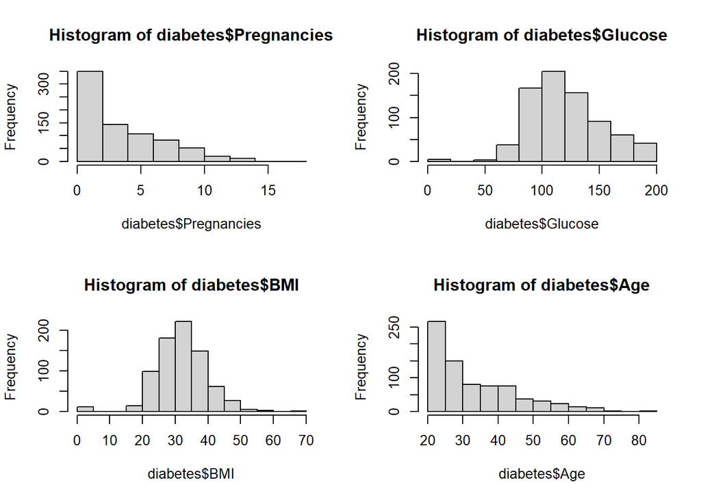

```r
#library(patchwork)
par(mfrow=c(2,2))
p1 <- hist(diabetes$Pregnancies)
p2 <- hist(diabetes$Glucose)
p3 <- hist(diabetes$BMI)
p4 <- hist(diabetes$Age)
```

From these distribution graphs, Age and number of times pregnant are not in normal distributions as expected since the underlying population should not be normally distributed either.

Glucose level and BMI are following a normal distribution.

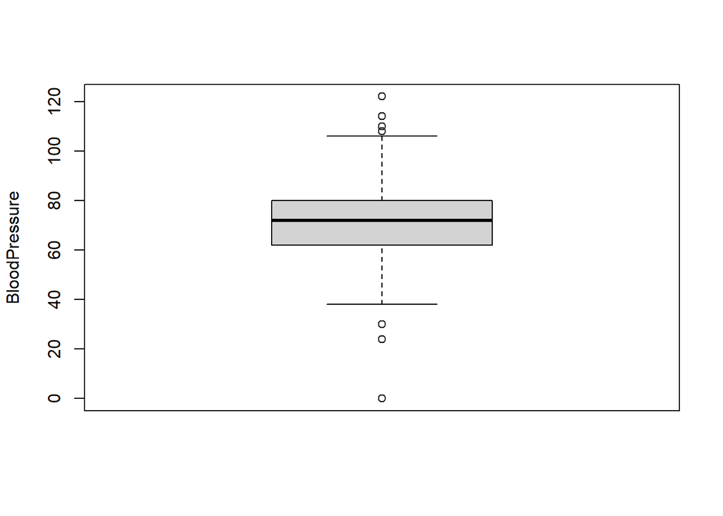

```r
boxplot(diabetes$BloodPressure, ylab="BloodPressure")
```

### **Impact of Glucose on Diabetes**

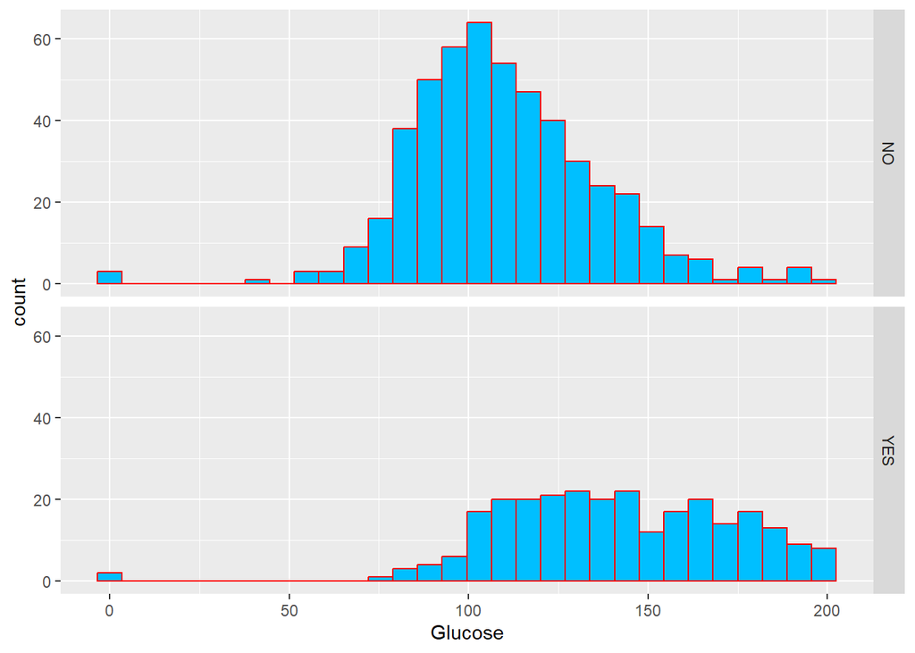

```r
ggplot(diabetes, aes(x=Glucose))+
     geom_histogram(fill='deepskyblue', col='red') +
      facet_grid(Outcome~.)
```

Formulate a hypothesis to assess the mean difference of glucose levels between the positive and negative groups.

**Conditions**

Individuals are independent of each other

Here distributions are skewed but the sample >30

Both the groups are independent of each other and the sample size is lesser than 10% of the population,

```r
library(report)
t <- t.test(Glucose~Outcome, data = diabetes)
t
```

```
##
##  Welch Two Sample t-test
##
## data:  Glucose by Outcome
## t = -13.752, df = 461.33, p-value < 2.2e-16
## alternative hypothesis: true difference in means between group NO and group YES is not equal to 0
## 95 percent confidence interval:
##  -35.74707 -26.80786
## sample estimates:
##  mean in group NO mean in group YES
##          109.9800          141.2575
```

```r
report(t)
```

```
## Effect sizes were labelled following Cohen's (1988) recommendations.
##
## The Welch Two Sample t-test testing the difference of Glucose by Outcome (mean
## in group NO = 109.98, mean in group YES = 141.26) suggests that the effect is
## negative, statistically significant, and large (difference = -31.28, 95% CI
## [-35.75, -26.81], t(461.33) = -13.75, p < .001; Cohen's d = -1.28, 95% CI
## [-1.48, -1.08])
```

p-value is < critical values of 0.05, so we reject the null hypothesis for the alternate hypothesis. We can say that we are, 95 % confident, that the average glucose levels for individuals with diabetes is > the people without diabetes.

```r
t1 <- t.test(Age~Outcome, data = diabetes)
t1
```

```
##
##  Welch Two Sample t-test
##
## data:  Age by Outcome
## t = -6.9207, df = 575.78, p-value = 1.202e-11
## alternative hypothesis: true difference in means between group NO and group YES is not equal to 0
## 95 percent confidence interval:
##  -7.545092 -4.209236
## sample estimates:
##  mean in group NO mean in group YES
##          31.19000          37.06716
```

```r
report(t1)
```

```
## Effect sizes were labelled following Cohen's (1988) recommendations.
##
## The Welch Two Sample t-test testing the difference of Age by Outcome (mean in
## group NO = 31.19, mean in group YES = 37.07) suggests that the effect is
## negative, statistically significant, and medium (difference = -5.88, 95% CI
## [-7.55, -4.21], t(575.78) = -6.92, p < .001; Cohen's d = -0.58, 95% CI [-0.74,
## -0.41])
```

p_value<0.001, suggest that diabetic people is mostly old.

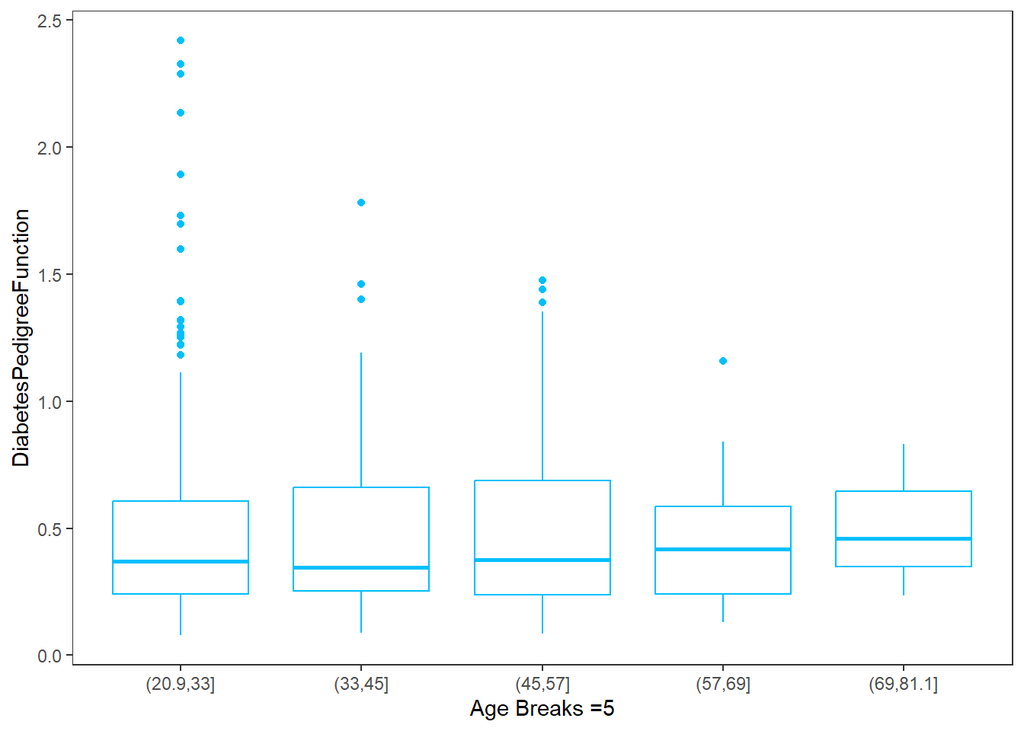

```r
theme_set(theme_test())
diabetes %>%
  ggplot(aes(x=cut(Age, breaks = 5))) +
        geom_boxplot(aes(y=DiabetesPedigreeFunction), col='deepskyblue')+
  labs(
    x = "Age Breaks =5",
    y = "DiabetesPedigreeFunction",
    colour = " ",
    shape = " "
   )
```

### Insulin Vs Glucose based on Outcome as diabetes

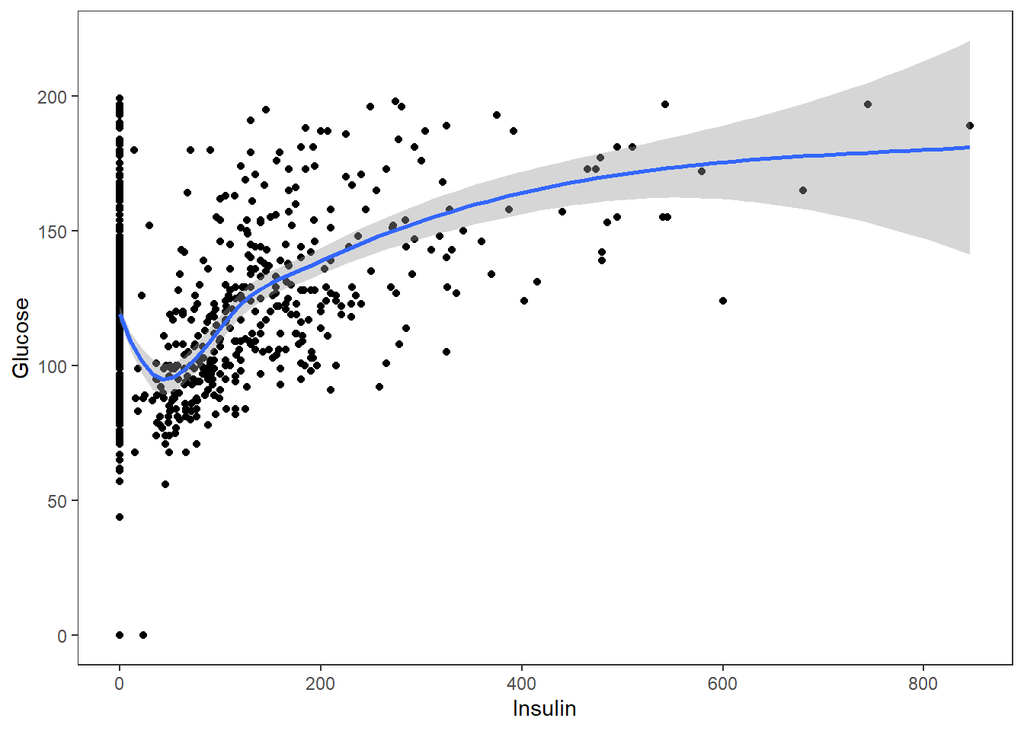

```r
diabetes %>%
  ggplot(aes(x=Insulin,y=Glucose)) +
    geom_point() +
  geom_smooth()
```

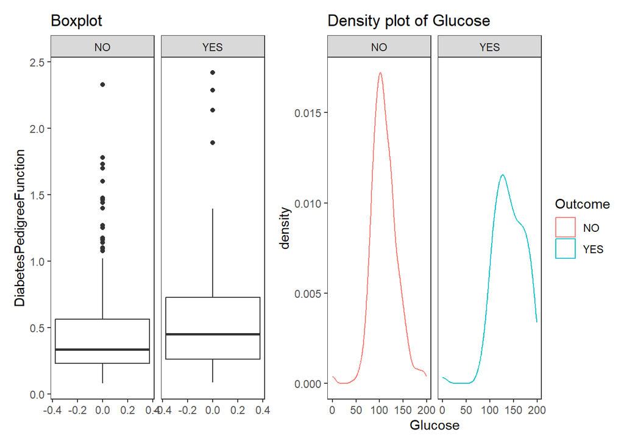

```r
# par(mfrow=c(1,2))
#boxplot
library(patchwork)
p0 <- diabetes %>%
  ggplot(aes(x=DiabetesPedigreeFunction))+
  geom_boxplot() +
  facet_wrap(~Outcome) + coord_flip() +
  ggtitle('Boxplot')

p1 <- diabetes %>%
  ggplot(aes(x=Glucose, col=Outcome))+
    geom_density()+
    facet_wrap(~Outcome) +
    ggtitle('Density plot of Glucose')

(p0 + p1)
```

From Density Plot the distribution is shifted towards the left for those without diabetes.

This indicates those **without diabetes generally have a lower blood glucose level**.

```r
#two sample t-test
t2 <- t.test(DiabetesPedigreeFunction~Outcome, data = diabetes) #%>% report()
t2
```

```
##
##  Welch Two Sample t-test
##
## data:  DiabetesPedigreeFunction by Outcome
## t = -4.5768, df = 454.51, p-value = 6.1e-06
## alternative hypothesis: true difference in means between group NO and group YES is not equal to 0
## 95 percent confidence interval:
##  -0.17262065 -0.06891135
## sample estimates:
##  mean in group NO mean in group YES
##          0.429734          0.550500
```

```r
report(t2)
```

```
## Effect sizes were labelled following Cohen's (1988) recommendations.
##
## The Welch Two Sample t-test testing the difference of DiabetesPedigreeFunction
## by Outcome (mean in group NO = 0.43, mean in group YES = 0.55) suggests that
## the effect is negative, statistically significant, and small (difference =
## -0.12, 95% CI [-0.17, -0.07], t(454.51) = -4.58, p < .001; Cohen's d = -0.43,
## 95% CI [-0.62, -0.24])
```

#### **Correlation between each variable**

Scatter matrix of all columns

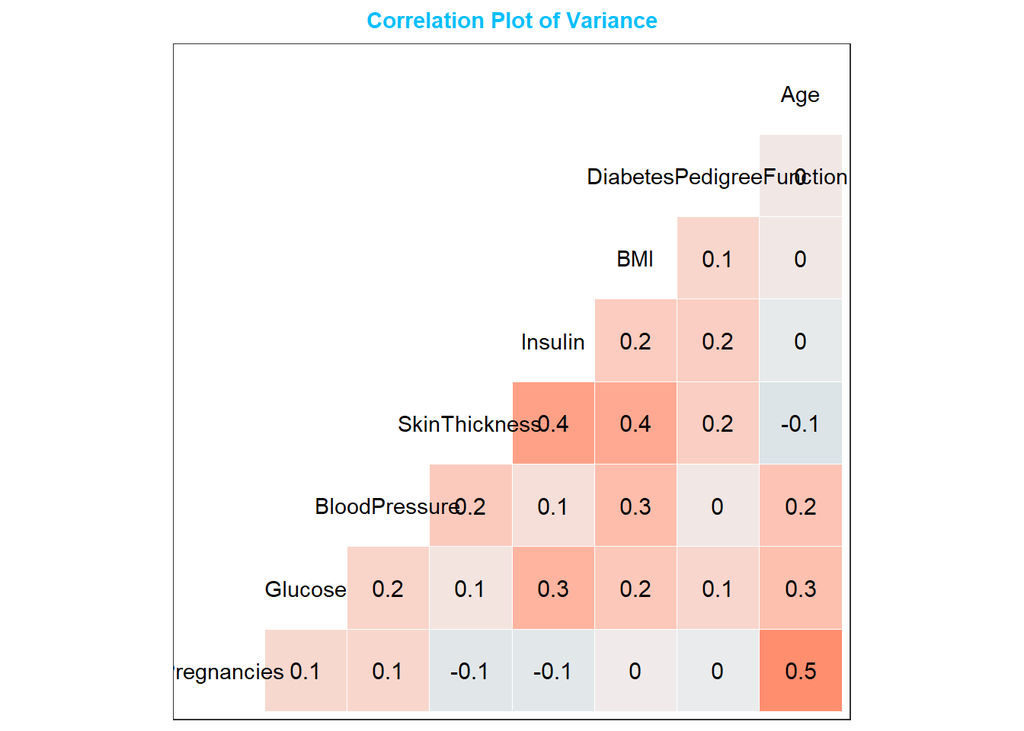

```r
library(GGally)
diabetes %>% select(-Outcome) %>%
  ggcorr(
    name = "corr", label = TRUE
  ) +
  theme(legend.position = 'none') +
  labs(title = 'Correlation Plot of Variance') +
  theme(plot.title = element_text(
    face = 'bold',                                color = 'deepskyblue',
    hjust = 0.5, size = 11))
```

Pregnancy, Age, Insulin, skinthickness are having higher correlation.

### **Fitting a logistic regression to assess importance of predictors**

This is a generic implementation — without assumption on data

```r
logit <- glm(Outcome~.,, data = diabetes, family = binomial())
summary(logit)
```

```
##
## Call:
## glm(formula = Outcome ~ ., family = binomial(), data = diabetes)
##
## Coefficients:
##                            Estimate Std. Error z value Pr(>|z|)
## (Intercept)              -8.4046964  0.7166359 -11.728  < 2e-16 ***
## Pregnancies               0.1231823  0.0320776   3.840 0.000123 ***
## Glucose                   0.0351637  0.0037087   9.481  < 2e-16 ***
## BloodPressure            -0.0132955  0.0052336  -2.540 0.011072 *
## SkinThickness             0.0006190  0.0068994   0.090 0.928515
## Insulin                  -0.0011917  0.0009012  -1.322 0.186065
## BMI                       0.0897010  0.0150876   5.945 2.76e-09 ***
## DiabetesPedigreeFunction  0.9451797  0.2991475   3.160 0.001580 **
## Age                       0.0148690  0.0093348   1.593 0.111192
## ---
## Signif. codes:  0 '***' 0.001 '**' 0.01 '*' 0.05 '.' 0.1 ' ' 1
##
## (Dispersion parameter for binomial family taken to be 1)
##
##     Null deviance: 993.48  on 767  degrees of freedom
## Residual deviance: 723.45  on 759  degrees of freedom
## AIC: 741.45
##
## Number of Fisher Scoring iterations: 5
```

```r
report(logit)
```

```
## We fitted a logistic model (estimated using ML) to predict Outcome with
## Pregnancies, Glucose, BloodPressure, SkinThickness, Insulin, BMI,
## DiabetesPedigreeFunction and Age (formula: Outcome ~ Pregnancies + Glucose +
## BloodPressure + SkinThickness + Insulin + BMI + DiabetesPedigreeFunction +
## Age). The model's explanatory power is substantial (Tjur's R2 = 0.33). The
## model's intercept, corresponding to Pregnancies = 0, Glucose = 0, BloodPressure
## = 0, SkinThickness = 0, Insulin = 0, BMI = 0, DiabetesPedigreeFunction = 0 and
## Age = 0, is at -8.40 (95% CI [-9.86, -7.05], p < .001). Within this model:
##
##   - The effect of Pregnancies is statistically significant and positive (beta =
## 0.12, 95% CI [0.06, 0.19], p < .001; Std. beta = 0.42, 95% CI [0.21, 0.63])
##   - The effect of Glucose is statistically significant and positive (beta = 0.04,
## 95% CI [0.03, 0.04], p < .001; Std. beta = 1.12, 95% CI [0.90, 1.36])
##   - The effect of BloodPressure is statistically significant and negative (beta =
## -0.01, 95% CI [-0.02, -3.10e-03], p = 0.011; Std. beta = -0.26, 95% CI [-0.46,
## -0.06])
##   - The effect of SkinThickness is statistically non-significant and positive
## (beta = 6.19e-04, 95% CI [-0.01, 0.01], p = 0.929; Std. beta = 9.87e-03, 95% CI
## [-0.20, 0.23])
##   - The effect of Insulin is statistically non-significant and negative (beta =
## -1.19e-03, 95% CI [-2.97e-03, 5.82e-04], p = 0.186; Std. beta = -0.14, 95% CI
## [-0.34, 0.07])
##   - The effect of BMI is statistically significant and positive (beta = 0.09, 95%
## CI [0.06, 0.12], p < .001; Std. beta = 0.71, 95% CI [0.48, 0.95])
##   - The effect of DiabetesPedigreeFunction is statistically significant and
## positive (beta = 0.95, 95% CI [0.37, 1.54], p = 0.002; Std. beta = 0.31, 95% CI
## [0.12, 0.51])
##   - The effect of Age is statistically non-significant and positive (beta = 0.01,
## 95% CI [-3.50e-03, 0.03], p = 0.111; Std. beta = 0.17, 95% CI [-0.04, 0.39])
##
## Standardized parameters were obtained by fitting the model on a standardized
## version of the dataset. 95% Confidence Intervals (CIs) and p-values were
## computed using a Wald z-distribution approximation.
```

#### Filtering the most important predictors from GLM model Extracting the N most important GLM coefficients

### Features Selection

- Highest logistic model coefficients

```r
model_coef <- exp(coef(logit))[2:ncol(diabetes)]
model_coef <- model_coef[c(order(model_coef,decreasing = TRUE)[1:(ncol(diabetes)-1)])]
predictors_names <- c(names(model_coef), names(diabetes)[length(diabetes)])
predictors_names
```

```
## [1] "DiabetesPedigreeFunction" "Pregnancies"
## [3] "BMI"                      "Glucose"
## [5] "Age"                      "SkinThickness"
## [7] "Insulin"                  "BloodPressure"
## [9] "Outcome"
```

```r
#filter df with most important predictors
diabetes_df <- diabetes[, c(predictors_names)]
head(diabetes_df)
```

| DiabetesPedigreeFunction | Pregnancies | BMI | Glucose | Age | SkinThickness | Insulin | BloodPressure | Outcome |
| --- | --- | --- | --- | --- | --- | --- | --- | --- |
| 0.627 | 6 | 33.6 | 148 | 50 | 35 | 0 | 72 | YES |
| 0.351 | 1 | 26.6 | 85 | 31 | 29 | 0 | 66 | NO |
| 0.672 | 8 | 23.3 | 183 | 32 | 0 | 0 | 64 | YES |
| 0.167 | 1 | 28.1 | 89 | 21 | 23 | 94 | 66 | NO |
| 2.288 | 0 | 43.1 | 137 | 33 | 35 | 168 | 40 | YES |
| 0.201 | 5 | 25.6 | 116 | 30 | 0 | 0 | 74 | NO |

### Outlier Detection

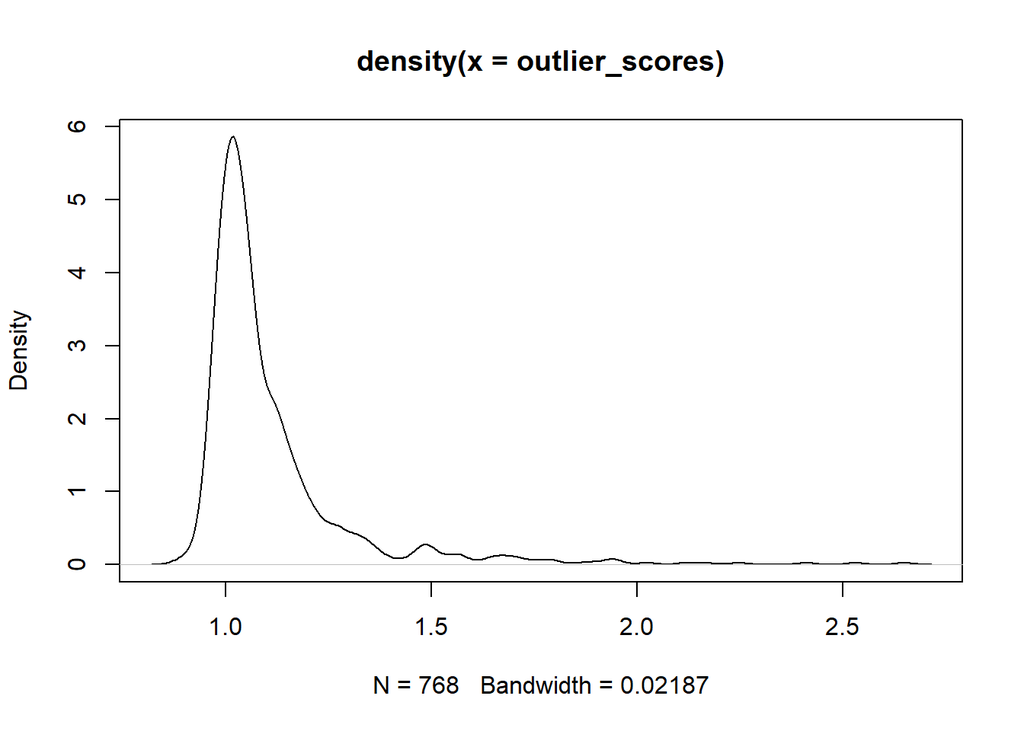

```r
library(DMwR2)
outlier_scores <- diabetes %>% select(-Outcome) %>%
            lofactor(k=5)
plot(density(outlier_scores))
```

```r
outliers <- order(outlier_scores,
                  decreasing = TRUE)[1:5]
print(outliers)
```

```
## [1]  14 580 146 454 107
```

## **The five outliers obtained in the output are the row numbers in the diabetes1 data derived from the diabetes data set.**

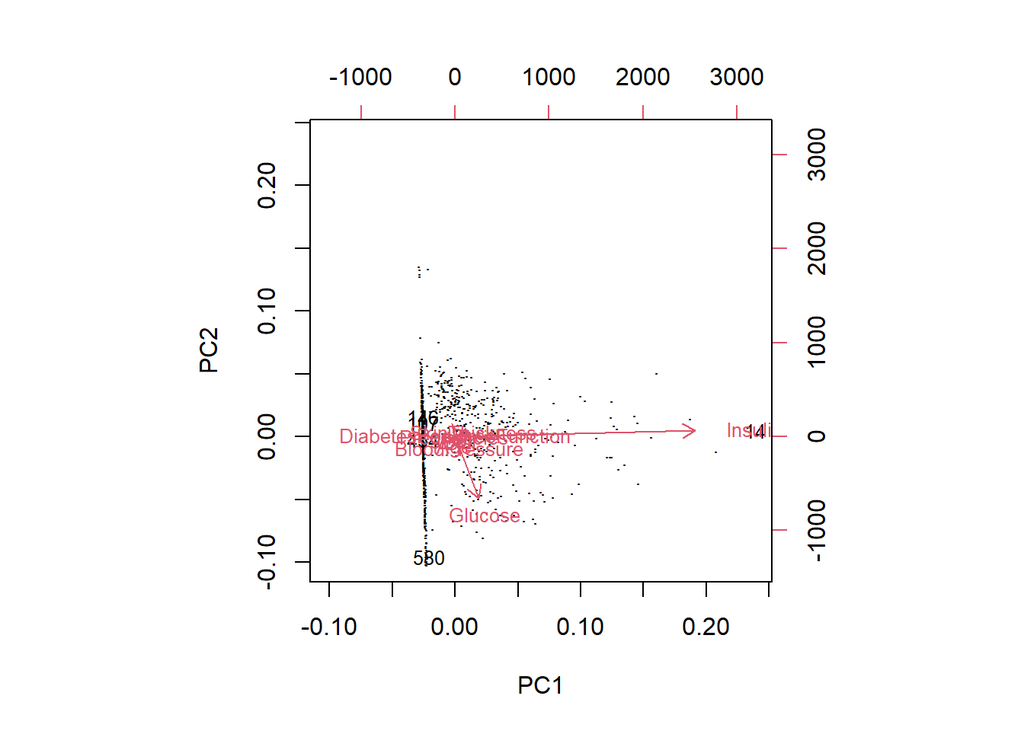

```r
# #labels outliers
n <- nrow(diabetes)
labels <- 1:n
labels[-outliers] <- "."
biplot(prcomp(diabetes[,-9], na.rm=TRUE), cex=.8, xlabs=labels)
```

```r
library(Rlof)
outlier.scores <- lof(diabetes[,-9], k=5)
outlier.scores<-lof(diabetes[,-9],k=c(5:10))
outlier.scores %>% head(4)
```

```
##             5        6        7         8         9        10
## [1,] 1.061391 1.029842 1.046721 1.0418848 1.0389602 1.0533413
## [2,] 1.070537 1.051352 1.034477 1.0391998 0.9969303 1.0016080
## [3,] 1.078872 1.115526 1.153996 1.1710755 1.1498865 1.1508931
## [4,] 1.030767 1.024495 1.031342 0.9995388 0.9937247 0.9915746
```

## Data Modelling

```r
#data partitioning/Train and Test
library(rsample)
split <- initial_split(diabetes, prop = 8/10)
train <- training(split)
test <- testing(split)
```

1. **Basic GLM with all Variables**

   ```r
   log <- glm(Outcome~., family = binomial(), data = train)
   summary(log)
   ```

   ```
   ##
   ## Call:
   ## glm(formula = Outcome ~ ., family = binomial(), data = train)
   ##
   ## Coefficients:
   ##                           Estimate Std. Error z value Pr(>|z|)
   ## (Intercept)              -8.436396   0.803869 -10.495  < 2e-16 ***
   ## Pregnancies               0.150950   0.038093   3.963 7.41e-05 ***
   ## Glucose                   0.038382   0.004413   8.697  < 2e-16 ***
   ## BloodPressure            -0.016360   0.006126  -2.671  0.00757 **
   ## SkinThickness             0.009369   0.007963   1.177  0.23938
   ## Insulin                  -0.001924   0.001012  -1.901  0.05725 .
   ## BMI                       0.091673   0.016888   5.428 5.69e-08 ***
   ## DiabetesPedigreeFunction  0.554768   0.342615   1.619  0.10540
   ## Age                       0.007323   0.010563   0.693  0.48813
   ## ---
   ## Signif. codes:  0 '***' 0.001 '**' 0.01 '*' 0.05 '.' 0.1 ' ' 1
   ##
   ## (Dispersion parameter for binomial family taken to be 1)
   ##
   ##     Null deviance: 788.83  on 613  degrees of freedom
   ## Residual deviance: 564.67  on 605  degrees of freedom
   ## AIC: 582.67
   ##
   ## Number of Fisher Scoring iterations: 5
   ```

## **Logistic Model**

input: explanatory variables xk and provides a prediction p with parameters $βk$.

The logit transformation constrains the value of p to the interval [0, 1].

$Y\^i$ = outcome of subject i.

Maximizing the likelihood = maximizing the log-likelihood(model)

```r
smodel <- step(log)
```

```
## Start:  AIC=582.67
## Outcome ~ Pregnancies + Glucose + BloodPressure + SkinThickness +
##     Insulin + BMI + DiabetesPedigreeFunction + Age
##
##                            Df Deviance    AIC
## - Age                       1   565.15 581.15
## - SkinThickness             1   566.06 582.06
## <none>                          564.67 582.67
## - DiabetesPedigreeFunction  1   567.34 583.34
## - Insulin                   1   568.27 584.27
## - BloodPressure             1   571.98 587.98
## - Pregnancies               1   581.11 597.11
## - BMI                       1   598.45 614.45
## - Glucose                   1   663.51 679.51
##
## Step:  AIC=581.15
## Outcome ~ Pregnancies + Glucose + BloodPressure + SkinThickness +
##     Insulin + BMI + DiabetesPedigreeFunction
##
##                            Df Deviance    AIC
## - SkinThickness             1   566.43 580.43
## <none>                          565.15 581.15
## - DiabetesPedigreeFunction  1   567.84 581.84
## - Insulin                   1   568.94 582.94
## - BloodPressure             1   572.03 586.03
## - Pregnancies               1   591.28 605.28
## - BMI                       1   598.52 612.52
## - Glucose                   1   671.59 685.59
##
## Step:  AIC=580.43
## Outcome ~ Pregnancies + Glucose + BloodPressure + Insulin + BMI +
##     DiabetesPedigreeFunction
##
##                            Df Deviance    AIC
## <none>                          566.43 580.43
## - Insulin                   1   569.01 581.01
## - DiabetesPedigreeFunction  1   569.46 581.46
## - BloodPressure             1   572.67 584.67
## - Pregnancies               1   592.10 604.10
## - BMI                       1   607.66 619.66
## - Glucose                   1   673.17 685.17
```

## **Initial Parameter Tuning**

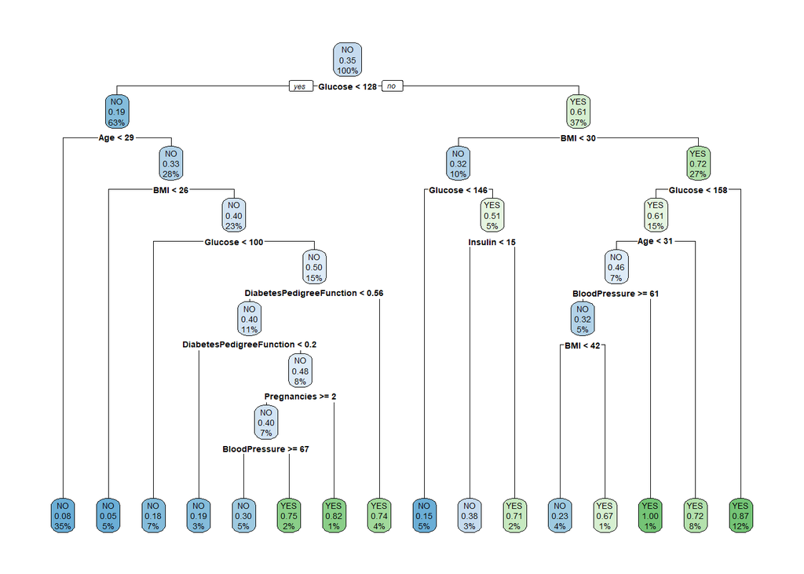

```r
library(rpart)
library(rpart.plot)
tree <- rpart(Outcome~., method = 'class', data = diabetes)
rpart.plot(tree)
```

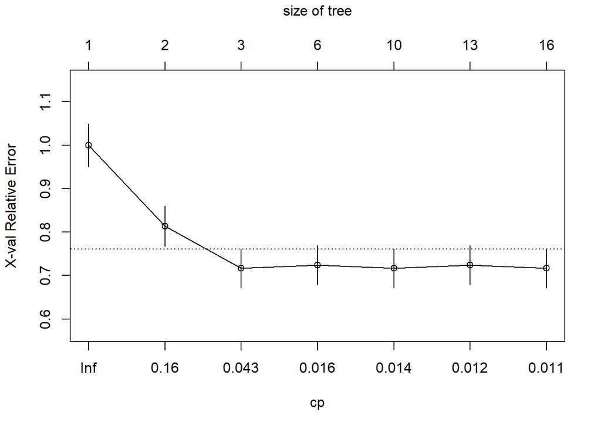

```r
plotcp(tree)
```

**Complexity parameter**

The above tree was tuned using a reference of the Relative error VS Complexity parameter. From the above figure the Cp value of 0.016, the decision tree was pruned. The final decision tree

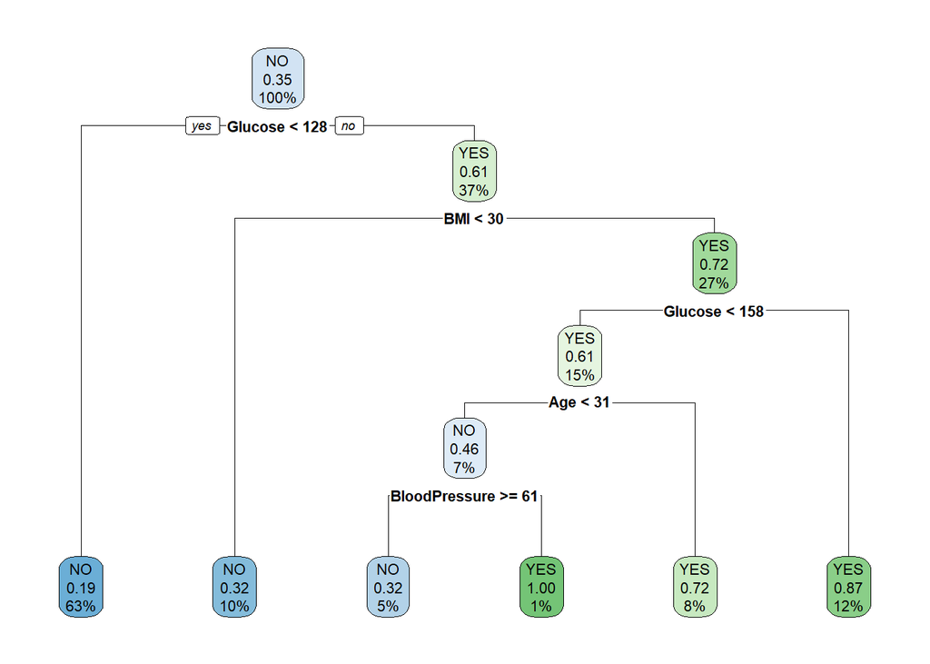

```r
tree1 <- rpart(Outcome~., method = 'class', data = diabetes, cp=0.016)
rpart.plot(tree1)
```

If CP value is lower, tree will grow large. A cp = 1 will provide no tree which helps in pruning the tree. Higher complexity parameters can lead to an over pruned tree.

```r
log1 <- glm(Outcome~., family = binomial(), data=(train %>% select(-c(Age,SkinThickness,
                BloodPressure ,                                         Insulin))))

summary(log1)
```

```
##
## Call:
## glm(formula = Outcome ~ ., family = binomial(), data = (train %>%
##     select(-c(Age, SkinThickness, BloodPressure, Insulin))))
##
## Coefficients:
##                           Estimate Std. Error z value Pr(>|z|)
## (Intercept)              -8.590189   0.737110 -11.654  < 2e-16 ***
## Pregnancies               0.151276   0.031228   4.844 1.27e-06 ***
## Glucose                   0.034441   0.003775   9.124  < 2e-16 ***
## BMI                       0.084908   0.015523   5.470 4.51e-08 ***
## DiabetesPedigreeFunction  0.545213   0.339144   1.608    0.108
## ---
## Signif. codes:  0 '***' 0.001 '**' 0.01 '*' 0.05 '.' 0.1 ' ' 1
##
## (Dispersion parameter for binomial family taken to be 1)
##
##     Null deviance: 788.83  on 613  degrees of freedom
## Residual deviance: 575.31  on 609  degrees of freedom
## AIC: 585.31
##
## Number of Fisher Scoring iterations: 5
```

```r
report(log1)
```

```
## We fitted a logistic model (estimated using ML) to predict Outcome with
## Pregnancies, Glucose, BMI and DiabetesPedigreeFunction (formula: Outcome ~
## Pregnancies + Glucose + BMI + DiabetesPedigreeFunction). The model's
## explanatory power is substantial (Tjur's R2 = 0.32). The model's intercept,
## corresponding to Pregnancies = 0, Glucose = 0, BMI = 0 and
## DiabetesPedigreeFunction = 0, is at -8.59 (95% CI [-10.10, -7.20], p < .001).
## Within this model:
##
##   - The effect of Pregnancies is statistically significant and positive (beta =
## 0.15, 95% CI [0.09, 0.21], p < .001; Std. beta = 0.50, 95% CI [0.30, 0.71])
##   - The effect of Glucose is statistically significant and positive (beta = 0.03,
## 95% CI [0.03, 0.04], p < .001; Std. beta = 1.09, 95% CI [0.86, 1.33])
##   - The effect of BMI is statistically significant and positive (beta = 0.08, 95%
## CI [0.06, 0.12], p < .001; Std. beta = 0.69, 95% CI [0.45, 0.94])
##   - The effect of DiabetesPedigreeFunction is statistically non-significant and
## positive (beta = 0.55, 95% CI [-0.11, 1.22], p = 0.108; Std. beta = 0.17, 95%
## CI [-0.04, 0.39])
##
## Standardized parameters were obtained by fitting the model on a standardized
## version of the dataset. 95% Confidence Intervals (CIs) and p-values were
## computed using a Wald z-distribution approximation.
```

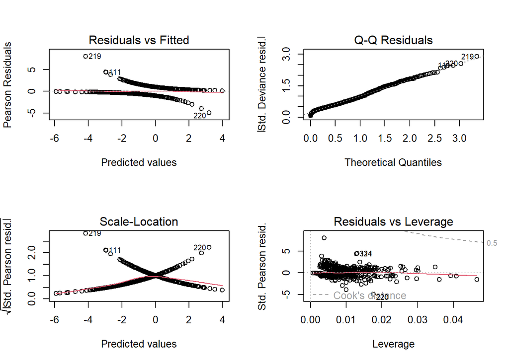

```r
par(mfrow=c(2,2))
plot(log1)
```

1. **Residuals vs fitted values**; Here dotted line at y=0 indicates fit line. The points on fit line indication of zero residual. Points above are having positive residuals similarly points below have negative residuals. . The red line is indicates smoothed high order polynomial curve which provides the idea behind pattern of residual movements. Here the residuals have logarithmic pattern hence we got a good model.

2. **Normal Q-Q Plot:** In general Normal Q-Q plot is used to check if our residuals follow Normal distribution or not. The residuals are said to be **normally distributed** if points follow the dotted line closely.

3. **Scale — Location Plot:** It indicates spread of points across predicted values range.

Assumption:

- Variance should be reasonably equal across the predictor range(Homoscedasticity)

4. **Residuals vs Leverage Plot**:

**Influence**: The Influence of an observation can be defined in terms of how much the predicted scores would change if the observation is excluded. Cook’s Distance

**Leverage**: The leverage of an observation is defined on how much the observation’s value on the predictor variable differs from the mean of the predictor variable. **The more the leverage of an observation , the greater potential that point has in terms of influence**.

**3rd Model: Predict Diabetes Risk on new patients using Decision Tree**

```r
library(party)
```

```r
ct <- ctree(Outcome~.,data=train)
# plot(ct)
predict_clas <- predict(ct, test,
                         type=c('response'))
table(predict_clas, test$Outcome)
```

```
##
## predict_clas NO YES
##          NO  77  19
##          YES 19  39
```

```r
library(caret)
con_mat <- confusionMatrix(test$Outcome, predict_clas, positive = NULL,
              dnn = c('Prediction', 'References'))
con_mat
```

```
## Confusion Matrix and Statistics
##
##           References
## Prediction NO YES
##        NO  77  19
##        YES 19  39
##
##                Accuracy : 0.7532
##                  95% CI : (0.6774, 0.8191)
##     No Information Rate : 0.6234
##     P-Value [Acc > NIR] : 0.0004308
##
##                   Kappa : 0.4745
##
##  Mcnemar's Test P-Value : 1.0000000
##
##             Sensitivity : 0.8021
##             Specificity : 0.6724
##          Pos Pred Value : 0.8021
##          Neg Pred Value : 0.6724
##              Prevalence : 0.6234
##          Detection Rate : 0.5000
##    Detection Prevalence : 0.6234
##       Balanced Accuracy : 0.7372
##
##        'Positive' Class : NO
##
```

### 4th Model Naïve Bayes:

```r
library(e1071)
nb <- naiveBayes(Outcome~., data = train)
pred <- predict(nb, test)
confusionMatrix(test$Outcome, pred)
```

```
## Confusion Matrix and Statistics
##
##           Reference
## Prediction NO YES
##        NO  75  21
##        YES 19  39
##
##                Accuracy : 0.7403
##                  95% CI : (0.6635, 0.8075)
##     No Information Rate : 0.6104
##     P-Value [Acc > NIR] : 0.0004806
##
##                   Kappa : 0.4506
##
##  Mcnemar's Test P-Value : 0.8743671
##
##             Sensitivity : 0.7979
##             Specificity : 0.6500
##          Pos Pred Value : 0.7812
##          Neg Pred Value : 0.6724
##              Prevalence : 0.6104
##          Detection Rate : 0.4870
##    Detection Prevalence : 0.6234
##       Balanced Accuracy : 0.7239
##
##        'Positive' Class : NO
##
```